# R Scripts

Hemachandra Ghanta Ayesha Ruhi Damda Jeremy Reep

October 30, 2018

# Summary on the Scripts

The water data is much more straight forward. For each day, there are a series of observations measuring the levels of a number of water-borne particulates. The current observation variables are total nitrogen and total phosphorus. The goal is to track the decline in particulates as the water moves through the waterbody. There is a northern and southern route so the analysis is split between these two geographies. Basic statistics are useful to help understand the data, but most of the analysis will be within the plots. The code for the water data will be after the code for the sand skink data.

```r
clpData <- read.csv("SS_Crooked Lake Sandhil.csv", header = TRUE)
str(clpData)
```

```
## 'data.frame':    24 obs. of  74 variables:
##  $ X             : Factor w/ 1 level "Crooked Lake Sandhill": 1 1 1 1 1 1 1 1 1 1 ...
##  $ Point.and.Quad: Factor w/ 24 levels "1E","1N","1S",..: 2 1 3 4 6 5 7 8 10 9 ...
##  $ X4.6.2006     : int  1 0 1 1 0 0 1 1 1 0 ...
##  $ X4.13.2006    : int  1 0 0 1 0 0 0 1 1 0 ...
##  $ X4.20.2006    : int  1 1 1 1 0 1 1 1 1 1 ...
##  $ X4.27.2006    : int  1 0 1 1 0 0 1 1 1 1 ...
##  $ X5.4.2006     : int  1 1 0 0 0 1 1 1 1 0 ...
##  $ X5.11.2006    : int  1 0 1 1 0 0 2 1 1 0 ...
##  $ X5.18.2006    : int  1 0 1 1 0 0 1 1 1 0 ...
##  $ X5.25.2006    : int  1 0 1 1 0 0 1 1 1 0 ...
##  $ X4.7.2011     : int  0 0 0 1 1 0 1 1 1 0 ...
##  $ X4.14.2011    : int  0 0 0 1 1 0 0 1 0 0 ...
##  $ X4.21.2011    : int  0 0 0 1 0 0 1 1 1 0 ...
##  $ X4.28.2011    : int  0 1 0 1 0 0 0 0 0 0 ...
```

[output cut: 60 more lines]

So in this case finding the average, max, min is not useful. Hence we continued to find the count of 0’s, 1’s, 2’s for each year to get the number of sand skinks found/not found in each year.

## Crooked Lake Sandhil area

Below is the summary on sand skinks in Crooked Lake Sandhil area.

### 2006

```r
clp2006 <- data.frame(y2006 = c(clpData[,"X4.6.2006"], clpData[,"X4.13.2006"], clpData[,"X4.13.2006"],
                                clpData[,"X4.13.2006"], clpData[,"X4.13.2006"], clpData[,"X4.13.2006"],
                                clpData[,"X4.13.2006"], clpData[,"X4.13.2006"]))
count(clp2006, vars = "y2006")
```

```
##   y2006 freq
## 1     0  116
## 2     1   75
## 3     2    1
```

Inference: 116 not found, 75 traces found, 1 found

### 2011

```r
clp2011 <- data.frame(y2011 = c(clpData[,"X4.7.2011"], clpData[,"X4.14.2011"], clpData[,"X4.21.2011"],
                                clpData[,"X4.28.2011"], clpData[,"X5.5.2011"], clpData[,"X5.12.2011"],
                                clpData[,"X5.19.2011"], clpData[,"X5.26.2011"]))
count(clp2011, vars = "y2011")
```

```
##   y2011 freq
## 1     0  119
## 2     1   49
## 3    NA   24
```

Inference: 119 not found, 49 traces, 24 No observations

### 2012

```r
clp2012 <- data.frame(y2012 = c(clpData[,"X4.5.2012"], clpData[,"X4.12.2012"], clpData[,"X4.19.2012"],
                                clpData[,"X4.26.2012"], clpData[,"X5.3.2012"], clpData[,"X5.10.2012"],
                                clpData[,"X5.17.2012"], clpData[,"X5.24.2012"]))
count(clp2012, vars = "y2012")
```

```
##   y2012 freq
## 1     0  113
## 2     1   79
```

Inference: 113 not found, 79 traces

### 2013

```r
clp2013 <- data.frame(y2013 = c(clpData[,"X4.4.2013"], clpData[,"X4.11.2013"], clpData[,"X4.18.2013"],
                                clpData[,"X4.25.2013"], clpData[,"X5.2.2013"], clpData[,"X5.19.2013"],
                                clpData[,"X5.23.2013"], clpData[,"X5.30.2013"]))
count(clp2013, vars = "y2013")
```

```
##   y2013 freq
## 1     0  131
## 2     1   61
```

### 2014

```r
clp2014 <- data.frame(y2014 = c(clpData[,"X4.3.2014"], clpData[,"X4.10.2014"], clpData[,"X4.24.2014"],
                                clpData[,"X5.1.2014"], clpData[,"X5.8.2014"], clpData[,"X5.22.2014"],
                                clpData[,"X5.29.2014"], clpData[,"X6.5.2014"]))
count(clp2014, vars = "y2014")
```

```
##   y2014 freq
## 1     0  155
## 2     1   37
```

Inference: 155 not found, 37 traces

### 2015

```r
clp2015 <- data.frame(y2015 = c(clpData[,"X4.7.2015"], clpData[,"X4.9.2015"], clpData[,"X4.16.2015"],
                                clpData[,"X4.23.2015"], clpData[,"X4.30.2015"], clpData[,"X5.14.2015"],
                                clpData[,"X5.21.2015"], clpData[,"X5.28.2015"]))
count(clp2015, vars = "y2015")
```

```
##   y2015 freq
## 1     0  153
## 2     1   39
```

Inference: 153 not found, 39 traces

### 2016

```r
clp2016 <- data.frame(y2016 = c(clpData[,"X4.7.2016"], clpData[,"X4.14.2016"], clpData[,"X4.21.2016"],
                                clpData[,"X4.28.2016"], clpData[,"X5.5.2016"], clpData[,"X5.12.2016"],
                                clpData[,"X5.19.2016"], clpData[,"X5.26.2016"]))
count(clp2016, vars = "y2016")
```

```
##   y2016 freq
## 1     0  153
## 2     1   38
## 3     2    1
```

Inference: 153 not found, 38 traces, 1 found

### 2017

```r
clp2017 <- data.frame(y2017 = c(clpData[,"X4.20.2017"], clpData[,"X4.27.2017"], clpData[,"X5.4.2017"],
                                clpData[,"X5.11.2017"], clpData[,"X5.18.2017"], clpData[,"X5.25.2017"]))
count(clp2017, vars = "y2017")
```

```
##   y2017 freq
## 1     0   72
## 2     1   70
## 3    NA    2
```

Inference: 72 not found, 70 traces, 2 not observed

### 2018

```r
clp2018 <- data.frame(y2018 = c(clpData[,"X4.5.2018"], clpData[,"X4.12.2018"], clpData[,"X4.19.2018"],
                                clpData[,"X4.26.2018"], clpData[,"X5.3.2018"], clpData[,"X5.10.2018"],
                                clpData[,"X5.17.2018"], clpData[,"X5.24.2018"]))
count(clp2018, vars = "y2018")
```

```
##   y2018 freq
## 1     0  126
## 2     1   54
## 3     2   11
## 4     3    1
```

## Water Data

```
## 'data.frame':    1568 obs. of  13 variables:
##  $ Index             : int  4 15 24 34 49 55 69 79 89 99 ...
##  $ Sequence          : int  1 4 3 2 4 5 1 3 2 1 ...
##  $ North             : int  0 0 0 1 1 1 1 1 0 0 ...
##  $ Period            : Factor w/ 11 levels "1","2","3","4",..: 1 1 1 1 1 1 1 1 1 1 ...
##  $ Waterbody         : Factor w/ 2 levels "Banana Creek",..: 1 2 2 2 2 2 2 2 2 1 ...
##  $ LabNo             : int  30221 30229 30226 30223 30227 30228 30222 30224 30225 30221 ...
##  $ Sampling.Site.Name: Factor w/ 9 levels "Banana Creek",..: 1 2 3 4 5 6 7 8 9 1 ...
##  $ Date.Collected    : Date, format: "2017-11-07" "2017-11-07" ...
##  $ Parameter         : Factor w/ 16 levels "Chlorophyll a (Corrected)",..: 1 1 1 1 1 1 1 1 1 2 ...
##  $ Unit              : Factor w/ 6 levels "%","deg C","mg/l",..: 5 5 5 5 5 5 5 5 5 6 ...
##  $ Result            : num  110 76.1 31.2 3 8.01 68.6 3 39.2 52.1 173 ...
##  $ DetectionLimit    : num  3 3 3 3 3 3 3 3 3 NA ...
##  $ DQCodes           : Factor w/ 21 levels "A","A I","A J3",..: NA NA NA 12 NA 1 12 NA NA NA ...
```

### Analysis for Total Nitrogen

#### Averages for total nitrogen in the northern route

```
##    Date.Collected AVG(Result)
## 1      2017-11-07      1.2700
## 2      2017-12-05      1.4140
## 3      2018-01-02      1.3900
## 4      2018-02-06      1.5580
## 5      2018-03-06      1.9880
## 6      2018-04-03      2.9560
## 7      2018-05-01      2.4975
## 8      2018-06-05      1.0700
## 9      2018-07-10      0.9400
## 10     2018-08-07      0.9920
## 11     2018-09-04      0.9020
```

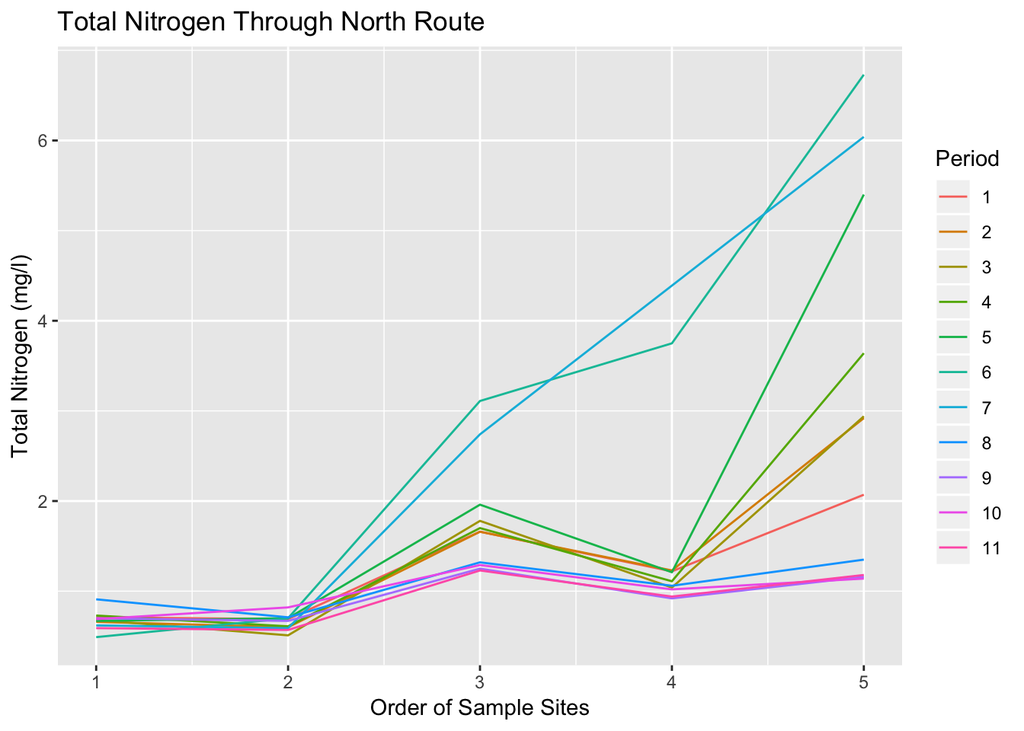

#### Averages for total nitrogen in the southern route

```
##    Date.Collected AVG(Result)
## 1      2017-11-07      2.8150
## 2      2017-12-05      3.3550
## 3      2018-01-02      5.1775
## 4      2018-02-06      2.8200
## 5      2018-03-06      2.6450
## 6      2018-04-03      4.4600
## 7      2018-05-01      5.3900
## 8      2018-06-05      1.6850
## 9      2018-07-10      1.5450
## 10     2018-08-07      1.7975
## 11     2018-09-04      1.7350
```

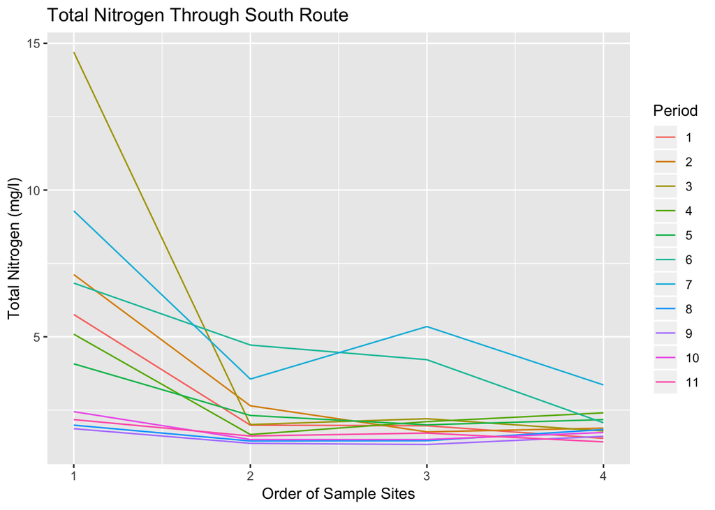

### Analysis for Total Phosphorous

#### Averages for total phosphorus in the northern route

```
##    Date.Collected AVG(Result)
## 1      2017-11-07      0.4884
## 2      2017-12-05      0.4070
## 3      2018-01-02      0.3716
## 4      2018-02-06      0.5102
## 5      2018-03-06      0.5328
## 6      2018-04-03      0.6122
## 7      2018-05-01      0.4220
## 8      2018-06-05      0.6500
## 9      2018-07-10      0.4902
## 10     2018-08-07      0.4314
## 11     2018-09-04      0.3564
```

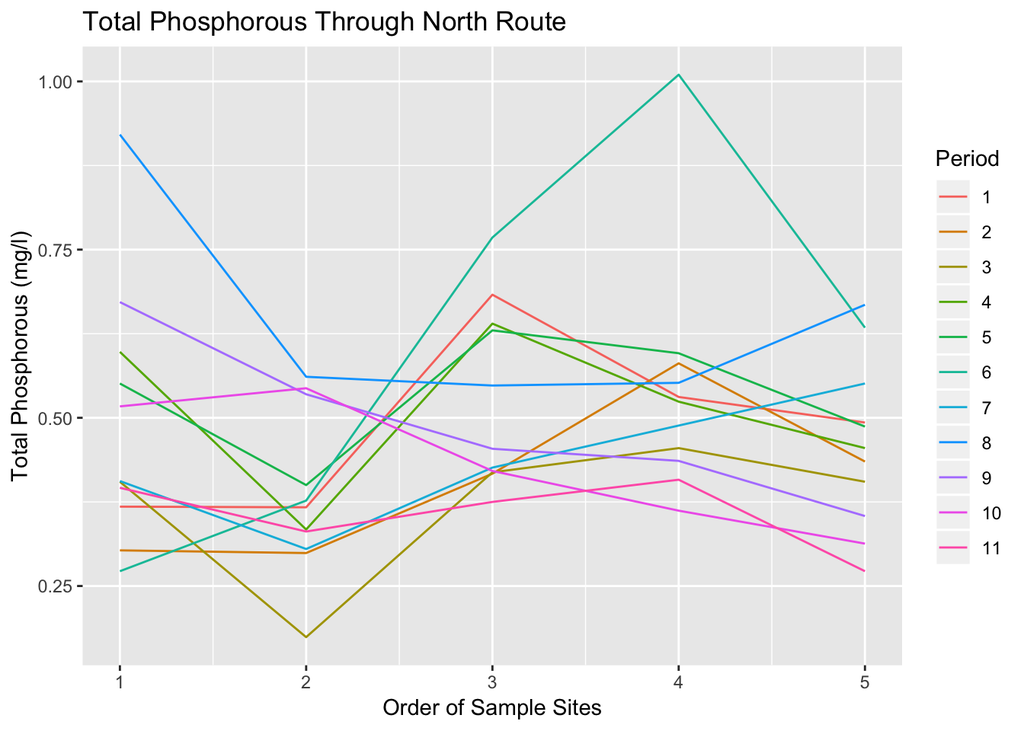

#### Averages for total phosphorus in the southern route

```
##    Date.Collected AVG(Result)
## 1      2017-11-07     0.80800
## 2      2017-12-05     0.79850
## 3      2018-01-02     1.20325
## 4      2018-02-06     0.77800
## 5      2018-03-06     0.82725
## 6      2018-04-03     0.67875
## 7      2018-05-01     0.82150
## 8      2018-06-05     0.62775
## 9      2018-07-10     0.56350
## 10     2018-08-07     0.48850
## 11     2018-09-04     0.42175
```

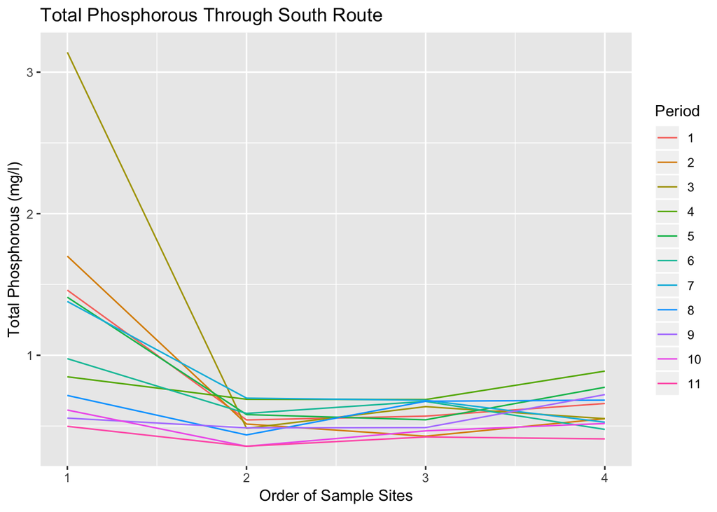